# BMP4 RT data

# 5 Fit LQ model

Fit the LQ model using non-linear least squares and print the results.

```r
predicted_survival_df = data.frame()
LQ_params = data.frame()

for (cline in clines[clines!="U87"]) {
  for (group in groups[!str_detect(groups,"20")]) {
    temp_data <- BMP_RT_data[BMP_RT_data$cline==cline & BMP_RT_data$group==group & BMP_RT_data$required_doses==TRUE,]

    quadratic.model <- nls(pe.norm_cline_group_biorep_by_dose0_mean ~ I(exp(-(A*dose+B*dose^2))), data = temp_data, start = list(A=0.1,B=0.01), lower = list(0,0), algorithm = "port", trace = FALSE)

    param_label <- c("A","B")
    LQ_params <- rbind(LQ_params,data.frame(cline=cline,group=group,coef=coef(quadratic.model),param_label=param_label))

    dosevalues <- seq(0,6,0.1)

    predicted_survival <- predict(quadratic.model, list(dose=dosevalues))

    predicted_survival_df <- rbind(predicted_survival_df,data.frame(cline=cline,dose=dosevalues,survival=predicted_survival,group=group))
  }
}

print(LQ_params)
```

```
     cline group        coef param_label
A    GBM1a  CTRL 0.224683447           A
B    GBM1a  CTRL 0.080023017           B
A1   GBM1a   FBS 0.220977286           A
B1   GBM1a   FBS 0.078784242           B
A2   GBM1a  E100 0.360194761           A
B2   GBM1a  E100 0.088044075           B
A3   GBM1a  B100 0.483977801           A
B3   GBM1a  B100 0.103982009           B
A4   GBM1a  S100 0.231694098           A
B4   GBM1a  S100 0.131032920           B
A5  GBM965  CTRL 0.080646355           A
B5  GBM965  CTRL 0.034737990           B
A6  GBM965   FBS 0.147236459           A
B6  GBM965   FBS 0.021318490           B
A7  GBM965  E100 0.055078740           A
B7  GBM965  E100 0.030225756           B
A8  GBM965  B100 0.000000000           A
B8  GBM965  B100 0.055366767           B
A9  GBM965  S100 0.110681033           A
B9  GBM965  S100 0.035279668           B
A10 QNS120  CTRL 0.000000000           A
B10 QNS120  CTRL 0.029743166           B
A11 QNS120   FBS 0.213548641           A
B11 QNS120   FBS 0.004980889           B
A12 QNS120  E100 0.250553775           A
B12 QNS120  E100 0.000000000           B
A13 QNS120  B100 0.114151050           A
B13 QNS120  B100 0.053788706           B
A14 QNS120  S100 0.306552977           A
B14 QNS120  S100 0.000000000           B
A15 GBM626  CTRL 0.419898790           A
B15 GBM626  CTRL 0.019330126           B
A16 GBM626   FBS 0.327733263           A
B16 GBM626   FBS 0.040074068           B
A17 GBM626  E100 0.873319619           A
B17 GBM626  E100 0.000000000           B
A18 GBM626  B100 0.981358210           A
B18 GBM626  B100 0.000000000           B
A19 GBM626  S100 1.226749463           A
B19 GBM626  S100 0.000000000           B
A20 GBM549  CTRL 0.287585359           A
B20 GBM549  CTRL 0.000000000           B
A21 GBM549   FBS 0.000000000           A
B21 GBM549   FBS 0.029050216           B
A22 GBM549  E100 0.021842749           A
B22 GBM549  E100 0.038691825           B
A23 GBM549  B100 0.248960166           A
B23 GBM549  B100 0.000000000           B
A24 GBM549  S100 0.320452634           A
B24 GBM549  S100 0.000000000           B
```

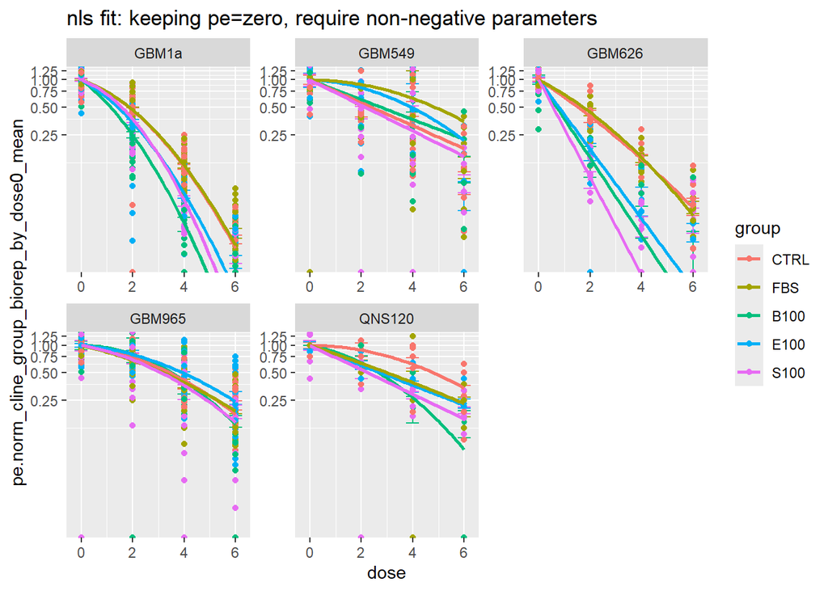

```r
pp <- ggplot(BMP_RT_data[!str_detect(BMP_RT_data$group,"20") & BMP_RT_data$required_doses==TRUE & BMP_RT_data$pe>=0,], aes(x=dose, y=pe.norm_cline_group_biorep_by_dose0_mean, group=group,colour=group)) +
  stat_summary(fun=mean, geom="point", shape=20, size=2) +
  stat_summary(fun.data = mean_se, geom = "errorbar", width=0.5) +
  geom_point() +
  labs(title=paste0("nls fit: keeping pe=zero, require non-negative parameters")) +
  scale_x_continuous(breaks=doses) +
  scale_y_continuous(breaks=seq(0,1.25,0.25)) +
  geom_line(data=predicted_survival_df,aes(x=dose,y=survival,group=group,colour=group),linewidth=1) +
  facet_wrap(vars(cline),scales = "free")

#print(pp)

print(pp + coord_trans(y="log10",ylim=c(0.01,1.1)))
```

GBM1a

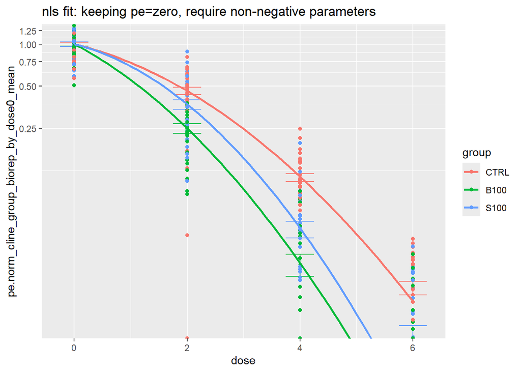

```r
cline = "GBM1a"

pp <- ggplot(BMP_RT_data[BMP_RT_data$cline==cline & !str_detect(BMP_RT_data$group,"20") & !str_detect(BMP_RT_data$group,"FBS") & !str_detect(BMP_RT_data$group,"E100") & BMP_RT_data$required_doses==TRUE & BMP_RT_data$pe>=0,], aes(x=dose, y=pe.norm_cline_group_biorep_by_dose0_mean, group=group,colour=group)) +
  stat_summary(fun=mean, geom="point", shape=20, size=2) +
  stat_summary(fun.data = mean_se, geom = "errorbar", width=0.5) +
  geom_point() +
  labs(title=paste0("nls fit: keeping pe=zero, require non-negative parameters")) +
  scale_x_continuous(breaks=doses) +
  scale_y_continuous(breaks=seq(0,1.25,0.25)) +
  geom_line(data=predicted_survival_df[predicted_survival_df$cline == cline & !str_detect(predicted_survival_df$group,"FBS") & !str_detect(predicted_survival_df$group,"E100"),],aes(x=dose,y=survival,group=group,colour=group),linewidth=1) +
  coord_trans(y="log10",ylim=c(0.01,1.1))

print(pp)
```

QNS120

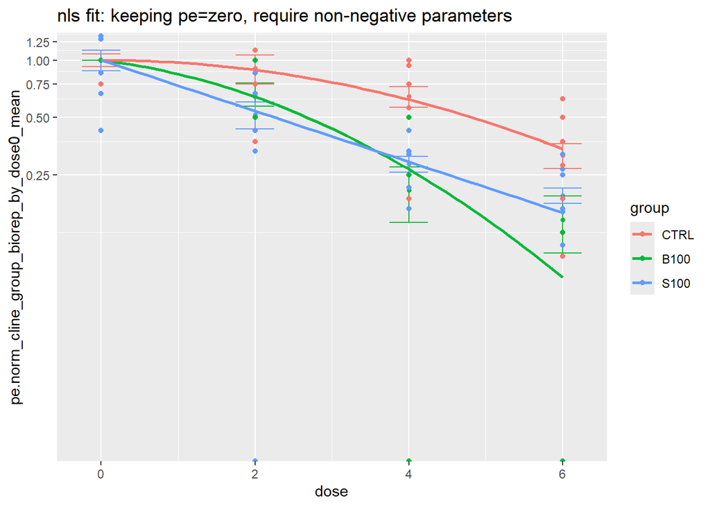

```r
cline = "QNS120"

pp <- ggplot(BMP_RT_data[BMP_RT_data$cline==cline & !str_detect(BMP_RT_data$group,"20") & !str_detect(BMP_RT_data$group,"FBS") & !str_detect(BMP_RT_data$group,"E100") & BMP_RT_data$required_doses==TRUE & BMP_RT_data$pe>=0,], aes(x=dose, y=pe.norm_cline_group_biorep_by_dose0_mean, group=group,colour=group)) +
  stat_summary(fun=mean, geom="point", shape=20, size=2) +
  stat_summary(fun.data = mean_se, geom = "errorbar", width=0.5) +
  geom_point() +
  labs(title=paste0("nls fit: keeping pe=zero, require non-negative parameters")) +
  scale_x_continuous(breaks=doses) +
  scale_y_continuous(breaks=seq(0,1.25,0.25)) +
  geom_line(data=predicted_survival_df[predicted_survival_df$cline == cline & !str_detect(predicted_survival_df$group,"FBS") & !str_detect(predicted_survival_df$group,"E100"),],aes(x=dose,y=survival,group=group,colour=group),linewidth=1) +
  coord_trans(y="log10",ylim=c(0.01,1.1))

print(pp)
```

GBM549

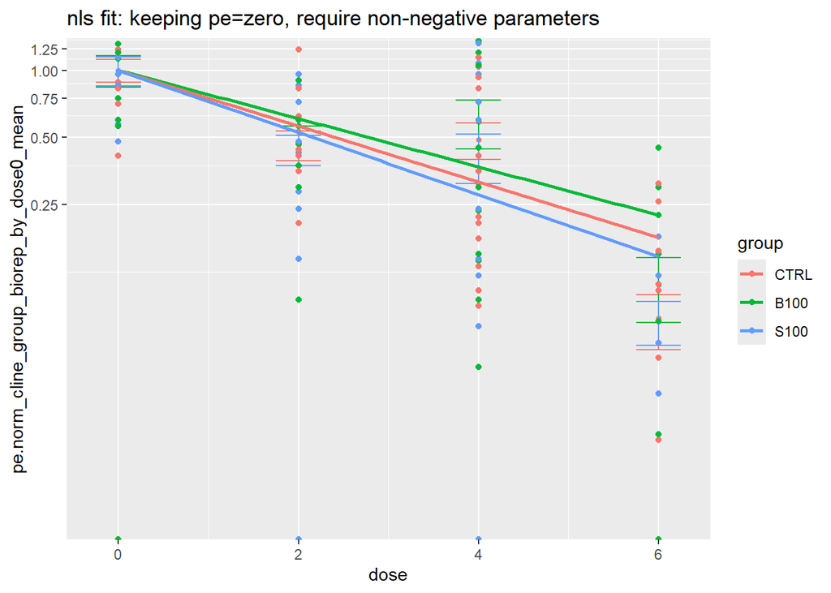

```r
cline = "GBM549"

pp <- ggplot(BMP_RT_data[BMP_RT_data$cline==cline & !str_detect(BMP_RT_data$group,"20") & !str_detect(BMP_RT_data$group,"FBS") & !str_detect(BMP_RT_data$group,"E100") & BMP_RT_data$required_doses==TRUE & BMP_RT_data$pe>=0,], aes(x=dose, y=pe.norm_cline_group_biorep_by_dose0_mean, group=group,colour=group)) +
  stat_summary(fun=mean, geom="point", shape=20, size=2) +
  stat_summary(fun.data = mean_se, geom = "errorbar", width=0.5) +
  geom_point() +
  labs(title=paste0("nls fit: keeping pe=zero, require non-negative parameters")) +
  scale_x_continuous(breaks=doses) +
  scale_y_continuous(breaks=seq(0,1.25,0.25)) +
  geom_line(data=predicted_survival_df[predicted_survival_df$cline == cline & !str_detect(predicted_survival_df$group,"FBS") & !str_detect(predicted_survival_df$group,"E100"),],aes(x=dose,y=survival,group=group,colour=group),linewidth=1) +
  coord_trans(y="log10",ylim=c(0.01,1.1))

print(pp)
```

GBM626

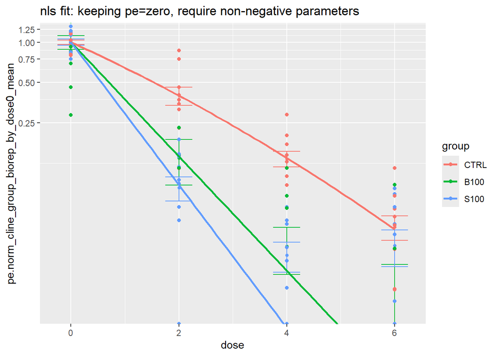

```r
cline = "GBM626"

pp <- ggplot(BMP_RT_data[BMP_RT_data$cline==cline & !str_detect(BMP_RT_data$group,"20") & !str_detect(BMP_RT_data$group,"FBS") & !str_detect(BMP_RT_data$group,"E100") & BMP_RT_data$required_doses==TRUE & BMP_RT_data$pe>=0,], aes(x=dose, y=pe.norm_cline_group_biorep_by_dose0_mean, group=group,colour=group)) +
  stat_summary(fun=mean, geom="point", shape=20, size=2) +
  stat_summary(fun.data = mean_se, geom = "errorbar", width=0.5) +
  geom_point() +
  labs(title=paste0("nls fit: keeping pe=zero, require non-negative parameters")) +
  scale_x_continuous(breaks=doses) +
  scale_y_continuous(breaks=seq(0,1.25,0.25)) +
  geom_line(data=predicted_survival_df[predicted_survival_df$cline == cline & !str_detect(predicted_survival_df$group,"FBS") & !str_detect(predicted_survival_df$group,"E100"),],aes(x=dose,y=survival,group=group,colour=group),linewidth=1) +
  coord_trans(y="log10",ylim=c(0.01,1.1))

print(pp)
```

GBM965

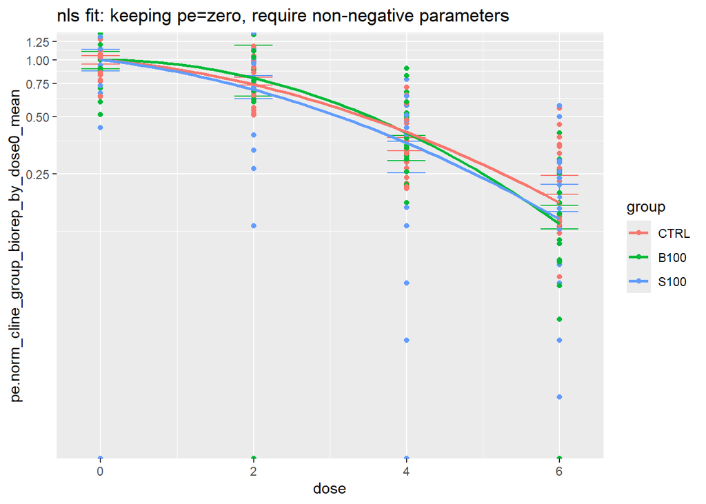

```r
cline = "GBM965"

pp <- ggplot(BMP_RT_data[BMP_RT_data$cline==cline & !str_detect(BMP_RT_data$group,"20") & !str_detect(BMP_RT_data$group,"FBS") & !str_detect(BMP_RT_data$group,"E100") & BMP_RT_data$required_doses==TRUE & BMP_RT_data$pe>=0,], aes(x=dose, y=pe.norm_cline_group_biorep_by_dose0_mean, group=group,colour=group)) +
  stat_summary(fun=mean, geom="point", shape=20, size=2) +
  stat_summary(fun.data = mean_se, geom = "errorbar", width=0.5) +
  geom_point() +
  labs(title=paste0("nls fit: keeping pe=zero, require non-negative parameters")) +
  scale_x_continuous(breaks=doses) +
  scale_y_continuous(breaks=seq(0,1.25,0.25)) +
  geom_line(data=predicted_survival_df[predicted_survival_df$cline == cline & !str_detect(predicted_survival_df$group,"FBS") & !str_detect(predicted_survival_df$group,"E100"),],aes(x=dose,y=survival,group=group,colour=group),linewidth=1) +
  coord_trans(y="log10",ylim=c(0.01,1.1))

print(pp)
```

# 6 Fit DLQ model

Fit a dual linear-quadratic model, this incorporates 2 cell populations.

We need to use the `optim` function to find the best parameters for this more complecated model as the nls function gives an error.

```r
DLQ_params = data.frame()

for (cline in clines[clines!="U87"]) {
  for (group in groups[!str_detect(groups,"20")]) {
    temp_data <- BMP_RT_data[BMP_RT_data$cline==cline & BMP_RT_data$group==group & BMP_RT_data$required_doses==TRUE,]

    # Define your custom objective function (e.g., sum of squared residuals)
    custom_obj <- function(params) {
      F <- params[1]
      alpha <- params[2]
      beta <- params[3]
      alpha2 <- params[4]
      beta2 <- params[5]
      D <- temp_data$dose
      pe <- temp_data$pe.norm_cline_group_biorep_by_dose0_mean
      #predicted <- F*exp(-(alpha*D + beta*D^2)) + (1-F)*exp(-(alpha*D + beta*D^2))
      predicted <- F*exp(-(alpha*D + beta*D^2)) + (1-F)*exp(-(alpha2*D + beta2*D^2))
      residuals <- pe - predicted
      sum(residuals^2) # minimise this
    }

    # Set initial parameter guesses
    initial_params <- c(1,0.1,0.01,0.1,0.01)

    # Optimize
    result <- optim(par = initial_params, fn = custom_obj,lower = c(0,0,0,0,0), upper = c(1,1,1,1,1), method = "L-BFGS-B")
    param_naems = c("F","alpha","beta","alpha2","beta2")
    DLQ_params <- rbind(DLQ_params,data.frame(cline=cline,group=group,coef=result$par,param_label=param_naems))

  }
}

print(head(DLQ_params))
```

```
  cline group       coef param_label
1 GBM1a  CTRL 0.00000000           F
2 GBM1a  CTRL 0.99917640       alpha
3 GBM1a  CTRL 0.99579061        beta
4 GBM1a  CTRL 0.22464737      alpha2
5 GBM1a  CTRL 0.08004602       beta2
6 GBM1a   FBS 0.25675446           F
```

I guess the idea would be that in the CTRL there is 100% GSCs so we do not need to fit the more commpleicated dual compartment model but when we add BMP4 there is an increase in RT effect caused by change in populations.

```r
DLQ_params_BMP = data.frame()

for (cline in clines[clines!="U87"]) {
  for (group in groups[!str_detect(groups,"20") & !str_detect(groups,"CTRL") & !str_detect(groups,"FBS") & !str_detect(groups,"E")]) {
    temp_data <- BMP_RT_data[BMP_RT_data$cline==cline & BMP_RT_data$group==group & BMP_RT_data$required_doses==TRUE,]

    # Define your custom objective function (e.g., sum of squared residuals)
    custom_obj <- function(params) {
      F <- params[1] # fraction of GSC
      alpha <- params[2] # sensativity of GSCs to RT
      beta <- params[3] # sensativity of GSCs to RT
      D <- temp_data$dose
      pe <- temp_data$pe.norm_cline_group_biorep_by_dose0_mean
      #predicted <- F*exp(-(alpha*D + beta*D^2)) + (1-F)*exp(-(alpha*D + beta*D^2))
      predicted <- F*exp(-0.13*(alpha*D + beta*D^2)) + (1-F)*exp(-(alpha*D + beta*D^2))
      residuals <- pe - predicted
      sum(residuals^2) # minimise this
    }

    # Set initial parameter guesses
    initial_params <- c(0.4,0.1,0.01)

    # Optimize
    result <- optim(par = initial_params, fn = custom_obj,lower = c(0,0,0), upper = c(0.9,1,1), method = "L-BFGS-B")
    param_naems = c("F","alpha","beta")
    DLQ_params_BMP <- rbind(DLQ_params_BMP,data.frame(cline=cline,group=group,coef=result$par,param_label=param_naems))

  }
}

print(DLQ_params_BMP)
```

```
    cline group       coef param_label
1   GBM1a  B100 0.53965863           F
2   GBM1a  B100 1.00000000       alpha
3   GBM1a  B100 1.00000000        beta
4   GBM1a  S100 0.80756485           F
5   GBM1a  S100 1.00000000       alpha
6   GBM1a  S100 1.00000000        beta
7  GBM965  B100 0.00000000           F
8  GBM965  B100 0.00000000       alpha
9  GBM965  B100 0.05537609        beta
10 GBM965  S100 0.29321101           F
11 GBM965  S100 0.00000000       alpha
12 GBM965  S100 0.12079466        beta
13 QNS120  B100 0.21417171           F
14 QNS120  B100 0.00000000       alpha
```

[output cut: 16 more lines]

Plot some example fits GBM1a

```r
my_DLQ_model <- function(D,F,alpha,beta) {
  F*exp(-0.13*(alpha*D + beta*D^2)) + (1-F)*exp(-(alpha*D + beta*D^2))
}

cline = "GBM1a"

x <- seq(from = 0, to = 6, length.out = 101)
y <- my_DLQ_model(x,DLQ_params_BMP[DLQ_params_BMP$cline==cline & DLQ_params_BMP$group=="B100",]$coef[1],DLQ_params_BMP[DLQ_params_BMP$cline==cline & DLQ_params_BMP$group=="B100",]$coef[2],DLQ_params_BMP[DLQ_params_BMP$cline==cline & DLQ_params_BMP$group=="B100",]$coef[3])
mat <- cbind(x, y)
df_B100 <- as.data.frame(mat)

print("Fraction of GSC with B100")
```

```
[1] "Fraction of GSC with B100"
```

```r
print(DLQ_params_BMP[DLQ_params_BMP$cline==cline & DLQ_params_BMP$group=="B100",]$coef[1])
```

```
[1] 0.5396586
```

```r
x <- seq(from = 0, to = 6, length.out = 11)
y <- my_DLQ_model(x,DLQ_params_BMP[DLQ_params_BMP$cline==cline & DLQ_params_BMP$group=="S100",]$coef[1],DLQ_params_BMP[DLQ_params_BMP$cline==cline & DLQ_params_BMP$group=="S100",]$coef[2],DLQ_params_BMP[DLQ_params_BMP$cline==cline & DLQ_params_BMP$group=="S100",]$coef[3])
mat <- cbind(x, y)
df_S100 <- as.data.frame(mat)

print("Fraction of GSC with S100")
```

```
[1] "Fraction of GSC with S100"
```

```r
print(DLQ_params_BMP[DLQ_params_BMP$cline==cline & DLQ_params_BMP$group=="S100",]$coef[1])
```

```
[1] 0.8075649
```

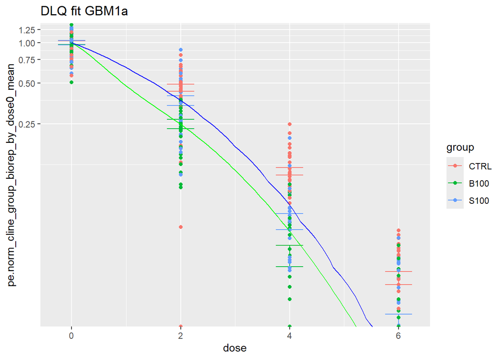

```r
pp <- ggplot(BMP_RT_data[BMP_RT_data$cline==cline & !str_detect(BMP_RT_data$group,"20") & !str_detect(BMP_RT_data$group,"FBS") & !str_detect(BMP_RT_data$group,"E100") & BMP_RT_data$required_doses==TRUE & BMP_RT_data$pe>=0,], aes(x=dose, y=pe.norm_cline_group_biorep_by_dose0_mean, group=group,colour=group)) +
  stat_summary(fun=mean, geom="point", shape=20, size=2) +
  stat_summary(fun.data = mean_se, geom = "errorbar", width=0.5) +
  geom_point() +
  labs(title=paste0("DLQ fit GBM1a")) +
  scale_x_continuous(breaks=doses) +
  scale_y_continuous(breaks=seq(0,1.25,0.25)) +
  geom_line(data=df_B100,aes(x=x,y=y),colour="green") +
  geom_line(data=df_S100,aes(x=x,y=y),colour="blue") +
  coord_trans(y="log10",ylim=c(0.01,1.1))

print(pp)
```

QNS120

```r
cline = "QNS120"

x <- seq(from = 0, to = 6, length.out = 101)
y <- my_DLQ_model(x,DLQ_params_BMP[DLQ_params_BMP$cline==cline & DLQ_params_BMP$group=="B100",]$coef[1],DLQ_params_BMP[DLQ_params_BMP$cline==cline & DLQ_params_BMP$group=="B100",]$coef[2],DLQ_params_BMP[DLQ_params_BMP$cline==cline & DLQ_params_BMP$group=="B100",]$coef[3])
mat <- cbind(x, y)
df_B100 <- as.data.frame(mat)

print("Fraction of GSC with B100")
```

```
[1] "Fraction of GSC with B100"
```

```r
print(DLQ_params_BMP[DLQ_params_BMP$cline==cline & DLQ_params_BMP$group=="B100",]$coef[1])
```

```
[1] 0.2141717
```

```r
x <- seq(from = 0, to = 6, length.out = 11)
y <- my_DLQ_model(x,DLQ_params_BMP[DLQ_params_BMP$cline==cline & DLQ_params_BMP$group=="S100",]$coef[1],DLQ_params_BMP[DLQ_params_BMP$cline==cline & DLQ_params_BMP$group=="S100",]$coef[2],DLQ_params_BMP[DLQ_params_BMP$cline==cline & DLQ_params_BMP$group=="S100",]$coef[3])
mat <- cbind(x, y)
df_S100 <- as.data.frame(mat)

print("Fraction of GSC with S100")
```

```
[1] "Fraction of GSC with S100"
```

```r
print(DLQ_params_BMP[DLQ_params_BMP$cline==cline & DLQ_params_BMP$group=="S100",]$coef[1])
```

```
[1] 0.3317488
```

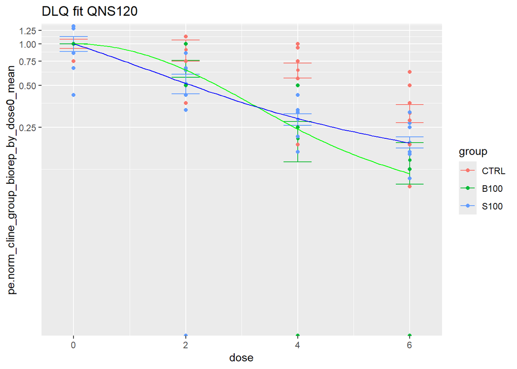

```r
pp <- ggplot(BMP_RT_data[BMP_RT_data$cline==cline & !str_detect(BMP_RT_data$group,"20") & !str_detect(BMP_RT_data$group,"FBS") & !str_detect(BMP_RT_data$group,"E100") & BMP_RT_data$required_doses==TRUE & BMP_RT_data$pe>=0,], aes(x=dose, y=pe.norm_cline_group_biorep_by_dose0_mean, group=group,colour=group)) +
  stat_summary(fun=mean, geom="point", shape=20, size=2) +
  stat_summary(fun.data = mean_se, geom = "errorbar", width=0.5) +
  geom_point() +
  labs(title=paste0("DLQ fit QNS120")) +
  scale_x_continuous(breaks=doses) +
  scale_y_continuous(breaks=seq(0,1.25,0.25)) +
  geom_line(data=df_B100,aes(x=x,y=y),colour="green") +
  geom_line(data=df_S100,aes(x=x,y=y),colour="blue") +
  coord_trans(y="log10",ylim=c(0.01,1.1))

print(pp)
```

GBM549

```r
cline = "GBM549"

x <- seq(from = 0, to = 6, length.out = 101)
y <- my_DLQ_model(x,DLQ_params_BMP[DLQ_params_BMP$cline==cline & DLQ_params_BMP$group=="B100",]$coef[1],DLQ_params_BMP[DLQ_params_BMP$cline==cline & DLQ_params_BMP$group=="B100",]$coef[2],DLQ_params_BMP[DLQ_params_BMP$cline==cline & DLQ_params_BMP$group=="B100",]$coef[3])
mat <- cbind(x, y)
df_B100 <- as.data.frame(mat)

print("Fraction of GSC with B100")
```

```
[1] "Fraction of GSC with B100"
```

```r
print(DLQ_params_BMP[DLQ_params_BMP$cline==cline & DLQ_params_BMP$group=="B100",]$coef[1])
```

```
[1] 0.7421029
```

```r
x <- seq(from = 0, to = 6, length.out = 11)
y <- my_DLQ_model(x,DLQ_params_BMP[DLQ_params_BMP$cline==cline & DLQ_params_BMP$group=="S100",]$coef[1],DLQ_params_BMP[DLQ_params_BMP$cline==cline & DLQ_params_BMP$group=="S100",]$coef[2],DLQ_params_BMP[DLQ_params_BMP$cline==cline & DLQ_params_BMP$group=="S100",]$coef[3])
mat <- cbind(x, y)
df_S100 <- as.data.frame(mat)

print("Fraction of GSC with S100")
```

```
[1] "Fraction of GSC with S100"
```

```r
print(DLQ_params_BMP[DLQ_params_BMP$cline==cline & DLQ_params_BMP$group=="S100",]$coef[1])
```

```
[1] 0.6600811
```

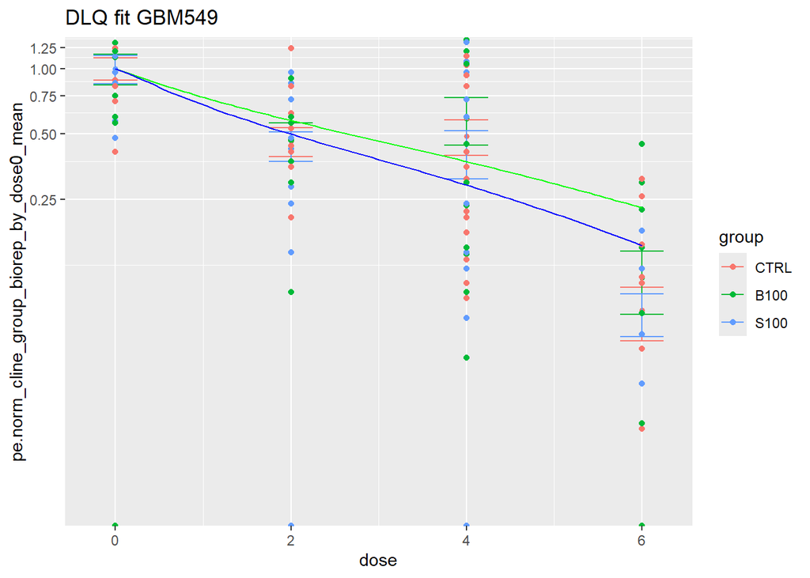

```r
pp <- ggplot(BMP_RT_data[BMP_RT_data$cline==cline & !str_detect(BMP_RT_data$group,"20") & !str_detect(BMP_RT_data$group,"FBS") & !str_detect(BMP_RT_data$group,"E100") & BMP_RT_data$required_doses==TRUE & BMP_RT_data$pe>=0,], aes(x=dose, y=pe.norm_cline_group_biorep_by_dose0_mean, group=group,colour=group)) +
  stat_summary(fun=mean, geom="point", shape=20, size=2) +
  stat_summary(fun.data = mean_se, geom = "errorbar", width=0.5) +
  geom_point() +
  labs(title=paste0("DLQ fit GBM549")) +
  scale_x_continuous(breaks=doses) +
  scale_y_continuous(breaks=seq(0,1.25,0.25)) +
  geom_line(data=df_B100,aes(x=x,y=y),colour="green") +
  geom_line(data=df_S100,aes(x=x,y=y),colour="blue") +
  coord_trans(y="log10",ylim=c(0.01,1.1))

print(pp)
```

GBM626

```r
cline = "GBM626"

x <- seq(from = 0, to = 6, length.out = 101)
y <- my_DLQ_model(x,DLQ_params_BMP[DLQ_params_BMP$cline==cline & DLQ_params_BMP$group=="B100",]$coef[1],DLQ_params_BMP[DLQ_params_BMP$cline==cline & DLQ_params_BMP$group=="B100",]$coef[2],DLQ_params_BMP[DLQ_params_BMP$cline==cline & DLQ_params_BMP$group=="B100",]$coef[3])
mat <- cbind(x, y)
df_B100 <- as.data.frame(mat)

print("Fraction of GSC with B100")
```

```
[1] "Fraction of GSC with B100"
```

```r
print(DLQ_params_BMP[DLQ_params_BMP$cline==cline & DLQ_params_BMP$group=="B100",]$coef[1])
```

```
[1] 0.2347303
```

```r
x <- seq(from = 0, to = 6, length.out = 11)
y <- my_DLQ_model(x,DLQ_params_BMP[DLQ_params_BMP$cline==cline & DLQ_params_BMP$group=="S100",]$coef[1],DLQ_params_BMP[DLQ_params_BMP$cline==cline & DLQ_params_BMP$group=="S100",]$coef[2],DLQ_params_BMP[DLQ_params_BMP$cline==cline & DLQ_params_BMP$group=="S100",]$coef[3])
mat <- cbind(x, y)
df_S100 <- as.data.frame(mat)

print("Fraction of GSC with S100")
```

```
[1] "Fraction of GSC with S100"
```

```r
print(DLQ_params_BMP[DLQ_params_BMP$cline==cline & DLQ_params_BMP$group=="S100",]$coef[1])
```

```
[1] 0.07141961
```

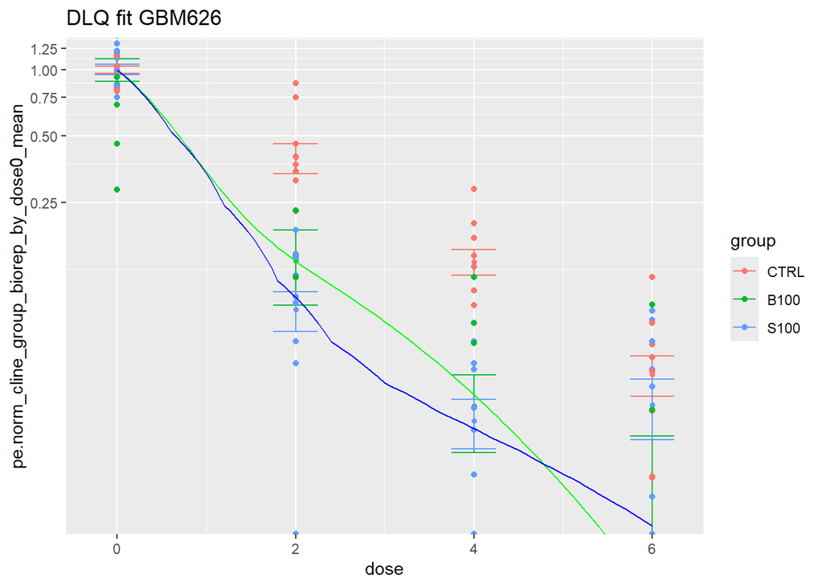

```r
pp <- ggplot(BMP_RT_data[BMP_RT_data$cline==cline & !str_detect(BMP_RT_data$group,"20") & !str_detect(BMP_RT_data$group,"FBS") & !str_detect(BMP_RT_data$group,"E100") & BMP_RT_data$required_doses==TRUE & BMP_RT_data$pe>=0,], aes(x=dose, y=pe.norm_cline_group_biorep_by_dose0_mean, group=group,colour=group)) +
  stat_summary(fun=mean, geom="point", shape=20, size=2) +
  stat_summary(fun.data = mean_se, geom = "errorbar", width=0.5) +
  geom_point() +
  labs(title=paste0("DLQ fit GBM626")) +
  scale_x_continuous(breaks=doses) +
  scale_y_continuous(breaks=seq(0,1.25,0.25)) +
  geom_line(data=df_B100,aes(x=x,y=y),colour="green") +
  geom_line(data=df_S100,aes(x=x,y=y),colour="blue") +
  coord_trans(y="log10",ylim=c(0.01,1.1))

print(pp)
```

# 7 Fit DLQ using alpha and beta from LQ CTRL fit

```r
# Extract the alpha and beta values from the LQ fit for the CTRL group
LQ_params_CTRL = LQ_params[LQ_params$group=="CTRL",]


DLQ_params_BMP = data.frame()

for (cline in clines[clines!="U87"]) {
  for (group in groups[!str_detect(groups,"20") & !str_detect(groups,"CTRL") & !str_detect(groups,"FBS") & !str_detect(groups,"E")]) {
    temp_data <- BMP_RT_data[BMP_RT_data$cline==cline & BMP_RT_data$group==group & BMP_RT_data$required_doses==TRUE,]

    # Define your custom objective function (e.g., sum of squared residuals)
    custom_obj <- function(params) {
      F <- params[1] # fraction of GSC
      alpha <- LQ_params_CTRL[LQ_params_CTRL$cline == cline,]$coef[1]
      beta <- LQ_params_CTRL[LQ_params_CTRL$cline == cline,]$coef[2]
      D <- temp_data$dose
      pe <- temp_data$pe.norm_cline_group_biorep_by_dose0_mean
      predicted <- F*exp(-(alpha*D + beta*D^2)) + (1-F)*exp(-(100/13)*(alpha*D + beta*D^2)) #if we are assuming alpha and beta from GSCs then we need to times them to get TC effect
      residuals <- pe - predicted
      sum(residuals^2) # minimise this
    }

    # Set initial parameter guesses
    initial_params <- c(0.7)

    # Optimize
    result <- optim(par = initial_params, fn = custom_obj,lower = c(0), upper = c(0.999), method = "L-BFGS-B")
    param_naems = c("F")
    DLQ_params_BMP <- rbind(DLQ_params_BMP,data.frame(cline=cline,group=group,coef=result$par,param_label=param_naems))

  }
}


print(DLQ_params_BMP)
```

```
    cline group      coef param_label
1   GBM1a  B100 0.5210781           F
2   GBM1a  S100 0.7813014           F
3  GBM965  B100 0.9990000           F
4  GBM965  S100 0.9164295           F
5  QNS120  B100 0.4063945           F
6  QNS120  S100 0.3930774           F
7  GBM626  B100 0.3285516           F
8  GBM626  S100 0.2071956           F
9  GBM549  B100 0.9990000           F
10 GBM549  S100 0.8759572           F
```

GBM1a

```r
cline = "GBM1a"

x <- seq(from = 0, to = 6, length.out = 101)
y <- my_DLQ_model(x,DLQ_params_BMP[DLQ_params_BMP$cline==cline & DLQ_params_BMP$group=="B100",]$coef[1], LQ_params_CTRL[LQ_params_CTRL$cline == cline,]$coef[1] * (100/13) ,LQ_params_CTRL[LQ_params_CTRL$cline == cline,]$coef[2] * (100/13))
mat <- cbind(x, y)
df_B100 <- as.data.frame(mat)

print("Fraction of GSC with B100")
```

```
[1] "Fraction of GSC with B100"
```

```r
print(DLQ_params_BMP[DLQ_params_BMP$cline==cline & DLQ_params_BMP$group=="B100",]$coef[1])
```

```
[1] 0.5210781
```

```r
x <- seq(from = 0, to = 6, length.out = 11)
y <- my_DLQ_model(x,DLQ_params_BMP[DLQ_params_BMP$cline==cline & DLQ_params_BMP$group=="S100",]$coef[1], LQ_params_CTRL[LQ_params_CTRL$cline == cline,]$coef[1] * (100/13) ,LQ_params_CTRL[LQ_params_CTRL$cline == cline,]$coef[2] * (100/13))
mat <- cbind(x, y)
df_S100 <- as.data.frame(mat)

print("Fraction of GSC with S100")
```

```
[1] "Fraction of GSC with S100"
```

```r
print(DLQ_params_BMP[DLQ_params_BMP$cline==cline & DLQ_params_BMP$group=="S100",]$coef[1])
```

```
[1] 0.7813014
```

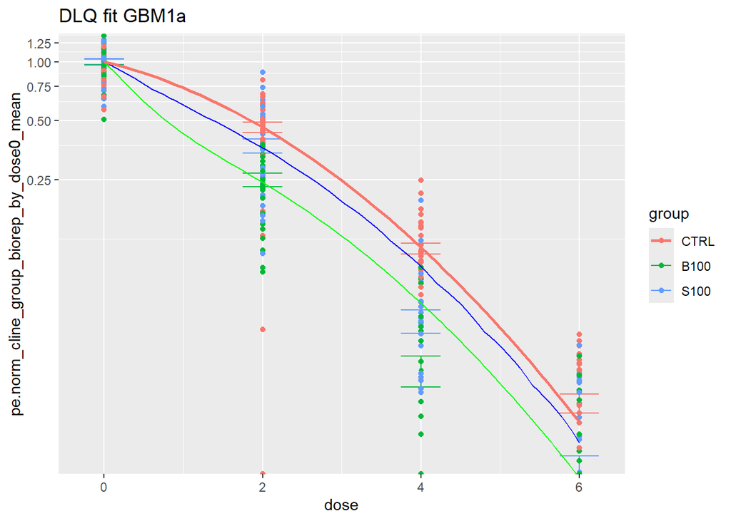

```r
pp <- ggplot(BMP_RT_data[BMP_RT_data$cline==cline & !str_detect(BMP_RT_data$group,"20") & !str_detect(BMP_RT_data$group,"FBS") & !str_detect(BMP_RT_data$group,"E100") & BMP_RT_data$required_doses==TRUE & BMP_RT_data$pe>=0,], aes(x=dose, y=pe.norm_cline_group_biorep_by_dose0_mean, group=group,colour=group)) +
  stat_summary(fun=mean, geom="point", shape=20, size=2) +
  stat_summary(fun.data = mean_se, geom = "errorbar", width=0.5) +
  geom_point() +
  labs(title=paste0("DLQ fit GBM1a")) +
  scale_x_continuous(breaks=doses) +
  scale_y_continuous(breaks=seq(0,1.25,0.25)) +
  geom_line(data=df_B100,aes(x=x,y=y),colour="green") +
  geom_line(data=df_S100,aes(x=x,y=y),colour="blue") +
  geom_line(data=predicted_survival_df[predicted_survival_df$cline == cline & str_detect(predicted_survival_df$group,"CTRL") ,],aes(x=dose,y=survival,group=group,colour=group),linewidth=1) +
  coord_trans(y="log10",ylim=c(0.01,1.1))

print(pp)
```

QNS120

```r
cline = "QNS120"

x <- seq(from = 0, to = 6, length.out = 101)
y <- my_DLQ_model(x,DLQ_params_BMP[DLQ_params_BMP$cline==cline & DLQ_params_BMP$group=="B100",]$coef[1], LQ_params_CTRL[LQ_params_CTRL$cline == cline,]$coef[1] * (100/13) ,LQ_params_CTRL[LQ_params_CTRL$cline == cline,]$coef[2] * (100/13))
mat <- cbind(x, y)
df_B100 <- as.data.frame(mat)

print("Fraction of GSC with B100")
```

```
[1] "Fraction of GSC with B100"
```

```r
print(DLQ_params_BMP[DLQ_params_BMP$cline==cline & DLQ_params_BMP$group=="B100",]$coef[1])
```

```
[1] 0.4063945
```

```r
x <- seq(from = 0, to = 6, length.out = 11)
y <- my_DLQ_model(x,DLQ_params_BMP[DLQ_params_BMP$cline==cline & DLQ_params_BMP$group=="S100",]$coef[1], LQ_params_CTRL[LQ_params_CTRL$cline == cline,]$coef[1] * (100/13) ,LQ_params_CTRL[LQ_params_CTRL$cline == cline,]$coef[2] * (100/13))
mat <- cbind(x, y)
df_S100 <- as.data.frame(mat)

print("Fraction of GSC with S100")
```

```
[1] "Fraction of GSC with S100"
```

```r
print(DLQ_params_BMP[DLQ_params_BMP$cline==cline & DLQ_params_BMP$group=="S100",]$coef[1])
```

```
[1] 0.3930774
```

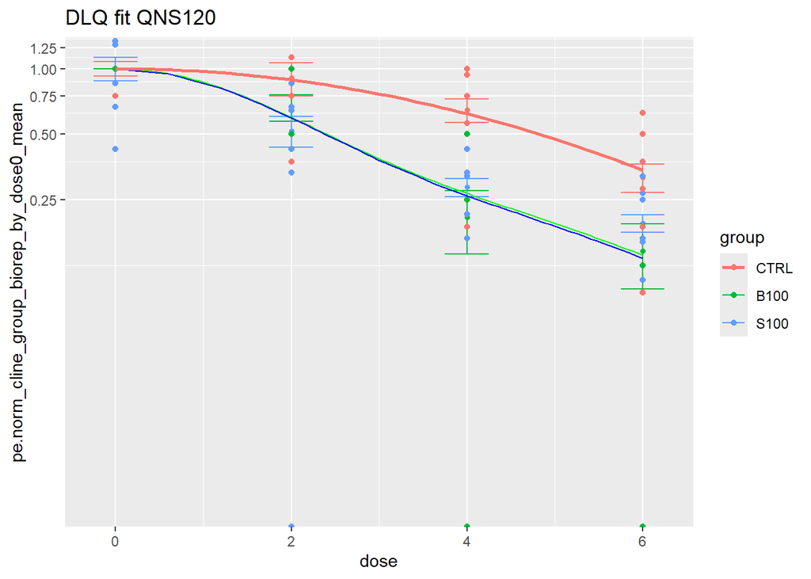

```r
pp <- ggplot(BMP_RT_data[BMP_RT_data$cline==cline & !str_detect(BMP_RT_data$group,"20") & !str_detect(BMP_RT_data$group,"FBS") & !str_detect(BMP_RT_data$group,"E100") & BMP_RT_data$required_doses==TRUE & BMP_RT_data$pe>=0,], aes(x=dose, y=pe.norm_cline_group_biorep_by_dose0_mean, group=group,colour=group)) +
  stat_summary(fun=mean, geom="point", shape=20, size=2) +
  stat_summary(fun.data = mean_se, geom = "errorbar", width=0.5) +
  geom_point() +
  labs(title=paste0("DLQ fit QNS120")) +
  scale_x_continuous(breaks=doses) +
  scale_y_continuous(breaks=seq(0,1.25,0.25)) +
  geom_line(data=df_B100,aes(x=x,y=y),colour="green") +
  geom_line(data=df_S100,aes(x=x,y=y),colour="blue") +
  geom_line(data=predicted_survival_df[predicted_survival_df$cline == cline & str_detect(predicted_survival_df$group,"CTRL") ,],aes(x=dose,y=survival,group=group,colour=group),linewidth=1) +
  coord_trans(y="log10",ylim=c(0.01,1.1))

print(pp)
```

GBM549

```r
cline = "GBM549"

x <- seq(from = 0, to = 6, length.out = 101)
y <- my_DLQ_model(x,DLQ_params_BMP[DLQ_params_BMP$cline==cline & DLQ_params_BMP$group=="B100",]$coef[1], LQ_params_CTRL[LQ_params_CTRL$cline == cline,]$coef[1] * (100/13) ,LQ_params_CTRL[LQ_params_CTRL$cline == cline,]$coef[2] * (100/13))
mat <- cbind(x, y)
df_B100 <- as.data.frame(mat)

print("Fraction of GSC with B100")
```

```
[1] "Fraction of GSC with B100"
```

```r
print(DLQ_params_BMP[DLQ_params_BMP$cline==cline & DLQ_params_BMP$group=="B100",]$coef[1])
```

```
[1] 0.999
```

```r
x <- seq(from = 0, to = 6, length.out = 11)
y <- my_DLQ_model(x,DLQ_params_BMP[DLQ_params_BMP$cline==cline & DLQ_params_BMP$group=="S100",]$coef[1], LQ_params_CTRL[LQ_params_CTRL$cline == cline,]$coef[1] * (100/13) ,LQ_params_CTRL[LQ_params_CTRL$cline == cline,]$coef[2] * (100/13))
mat <- cbind(x, y)
df_S100 <- as.data.frame(mat)

print("Fraction of GSC with S100")
```

```
[1] "Fraction of GSC with S100"
```

```r
print(DLQ_params_BMP[DLQ_params_BMP$cline==cline & DLQ_params_BMP$group=="S100",]$coef[1])
```

```
[1] 0.8759572
```

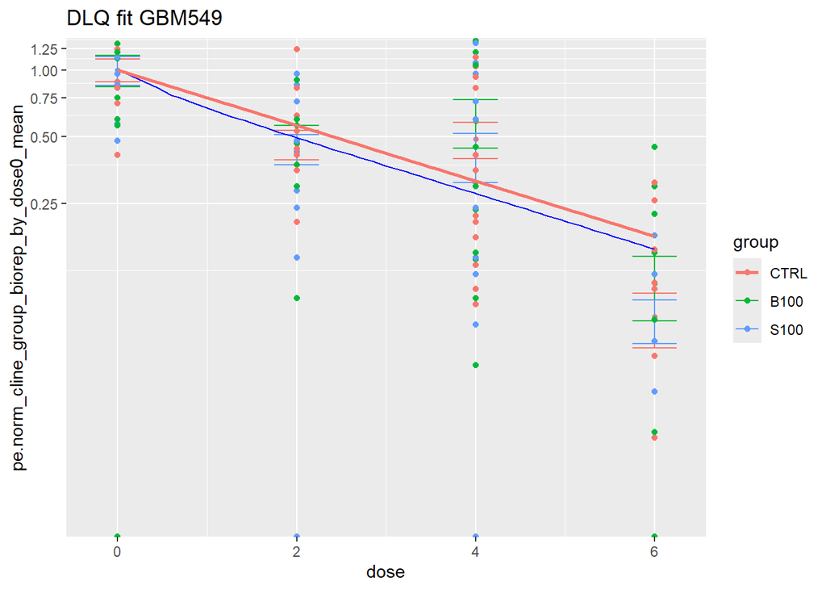

```r
pp <- ggplot(BMP_RT_data[BMP_RT_data$cline==cline & !str_detect(BMP_RT_data$group,"20") & !str_detect(BMP_RT_data$group,"FBS") & !str_detect(BMP_RT_data$group,"E100") & BMP_RT_data$required_doses==TRUE & BMP_RT_data$pe>=0,], aes(x=dose, y=pe.norm_cline_group_biorep_by_dose0_mean, group=group,colour=group)) +
  stat_summary(fun=mean, geom="point", shape=20, size=2) +
  stat_summary(fun.data = mean_se, geom = "errorbar", width=0.5) +
  geom_point() +
  labs(title=paste0("DLQ fit GBM549")) +
  scale_x_continuous(breaks=doses) +
  scale_y_continuous(breaks=seq(0,1.25,0.25)) +
  geom_line(data=df_B100,aes(x=x,y=y),colour="green") +
  geom_line(data=df_S100,aes(x=x,y=y),colour="blue") +
  geom_line(data=predicted_survival_df[predicted_survival_df$cline == cline & str_detect(predicted_survival_df$group,"CTRL") ,],aes(x=dose,y=survival,group=group,colour=group),linewidth=1) +
  coord_trans(y="log10",ylim=c(0.01,1.1))

print(pp)
```

GBM965

```r
cline = "GBM965"

x <- seq(from = 0, to = 6, length.out = 101)
y <- my_DLQ_model(x,DLQ_params_BMP[DLQ_params_BMP$cline==cline & DLQ_params_BMP$group=="B100",]$coef[1], LQ_params_CTRL[LQ_params_CTRL$cline == cline,]$coef[1] * (100/13) ,LQ_params_CTRL[LQ_params_CTRL$cline == cline,]$coef[2] * (100/13))
mat <- cbind(x, y)
df_B100 <- as.data.frame(mat)

print("Fraction of GSC with B100")
```

```
[1] "Fraction of GSC with B100"
```

```r
print(DLQ_params_BMP[DLQ_params_BMP$cline==cline & DLQ_params_BMP$group=="B100",]$coef[1])
```

```
[1] 0.999
```

```r
x <- seq(from = 0, to = 6, length.out = 11)
y <- my_DLQ_model(x,DLQ_params_BMP[DLQ_params_BMP$cline==cline & DLQ_params_BMP$group=="S100",]$coef[1], LQ_params_CTRL[LQ_params_CTRL$cline == cline,]$coef[1] * (100/13) ,LQ_params_CTRL[LQ_params_CTRL$cline == cline,]$coef[2] * (100/13))
mat <- cbind(x, y)
df_S100 <- as.data.frame(mat)

print("Fraction of GSC with S100")
```

```
[1] "Fraction of GSC with S100"
```

```r
print(DLQ_params_BMP[DLQ_params_BMP$cline==cline & DLQ_params_BMP$group=="S100",]$coef[1])
```

```
[1] 0.9164295
```

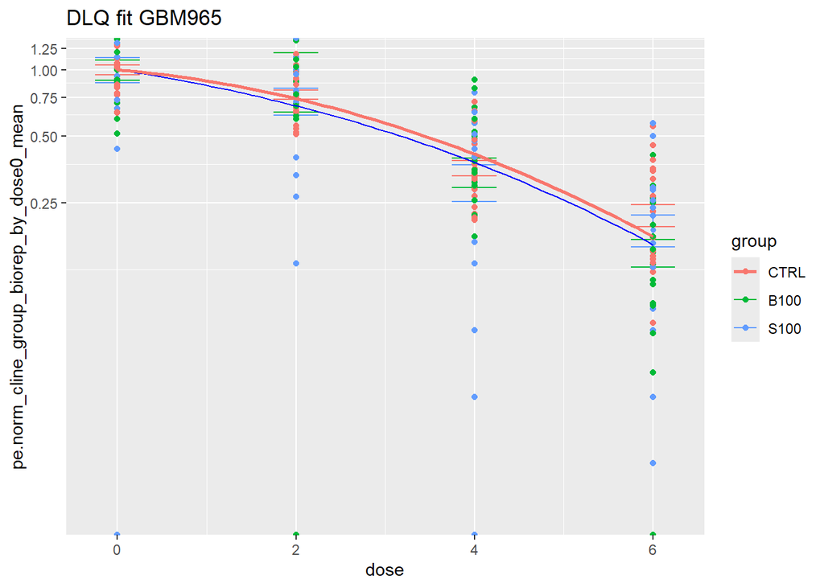

```r
pp <- ggplot(BMP_RT_data[BMP_RT_data$cline==cline & !str_detect(BMP_RT_data$group,"20") & !str_detect(BMP_RT_data$group,"FBS") & !str_detect(BMP_RT_data$group,"E100") & BMP_RT_data$required_doses==TRUE & BMP_RT_data$pe>=0,], aes(x=dose, y=pe.norm_cline_group_biorep_by_dose0_mean, group=group,colour=group)) +
  stat_summary(fun=mean, geom="point", shape=20, size=2) +
  stat_summary(fun.data = mean_se, geom = "errorbar", width=0.5) +
  geom_point() +
  labs(title=paste0("DLQ fit GBM965")) +
  scale_x_continuous(breaks=doses) +
  scale_y_continuous(breaks=seq(0,1.25,0.25)) +
  geom_line(data=df_B100,aes(x=x,y=y),colour="green") +
  geom_line(data=df_S100,aes(x=x,y=y),colour="blue") +
  geom_line(data=predicted_survival_df[predicted_survival_df$cline == cline & str_detect(predicted_survival_df$group,"CTRL") ,],aes(x=dose,y=survival,group=group,colour=group),linewidth=1) +
  coord_trans(y="log10",ylim=c(0.01,1.1))

print(pp)
```

GBM626

```r
cline = "GBM626"

x <- seq(from = 0, to = 6, length.out = 101)
y <- my_DLQ_model(x,DLQ_params_BMP[DLQ_params_BMP$cline==cline & DLQ_params_BMP$group=="B100",]$coef[1], LQ_params_CTRL[LQ_params_CTRL$cline == cline,]$coef[1] * (100/13) ,LQ_params_CTRL[LQ_params_CTRL$cline == cline,]$coef[2] * (100/13))
mat <- cbind(x, y)
df_B100 <- as.data.frame(mat)

print("Fraction of GSC with B100")
```

```
[1] "Fraction of GSC with B100"
```

```r
print(DLQ_params_BMP[DLQ_params_BMP$cline==cline & DLQ_params_BMP$group=="B100",]$coef[1])
```

```
[1] 0.3285516
```

```r
x <- seq(from = 0, to = 6, length.out = 11)
y <- my_DLQ_model(x,DLQ_params_BMP[DLQ_params_BMP$cline==cline & DLQ_params_BMP$group=="S100",]$coef[1], LQ_params_CTRL[LQ_params_CTRL$cline == cline,]$coef[1] * (100/13) ,LQ_params_CTRL[LQ_params_CTRL$cline == cline,]$coef[2] * (100/13))
mat <- cbind(x, y)
df_S100 <- as.data.frame(mat)

print("Fraction of GSC with S100")
```

```
[1] "Fraction of GSC with S100"
```

```r
print(DLQ_params_BMP[DLQ_params_BMP$cline==cline & DLQ_params_BMP$group=="S100",]$coef[1])
```

```
[1] 0.2071956
```

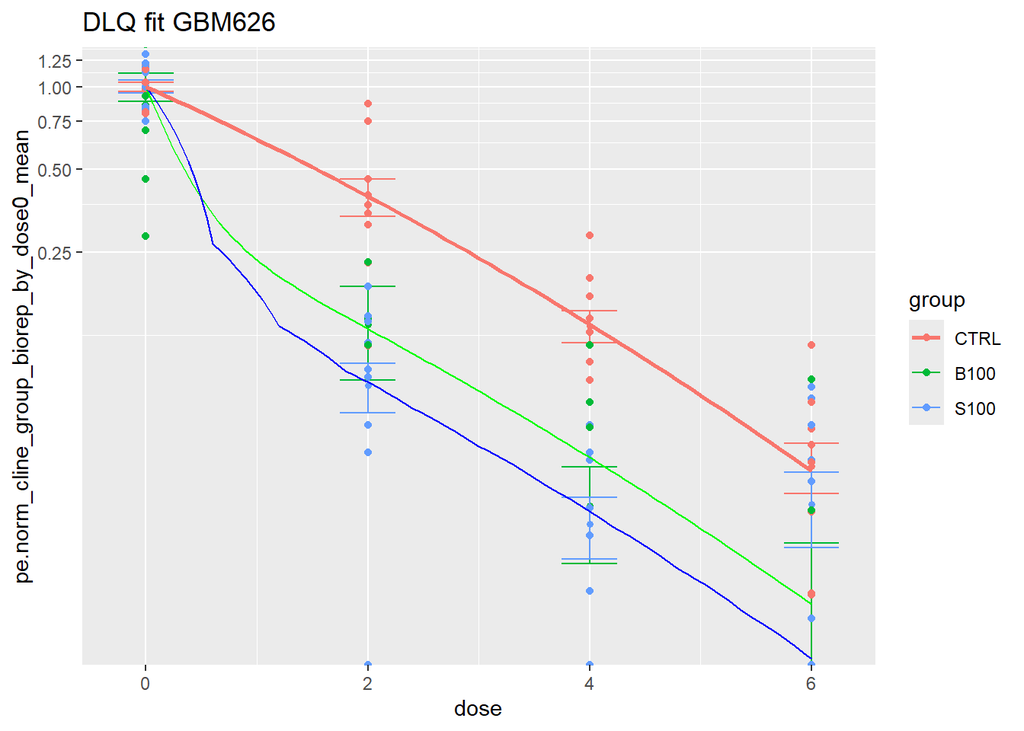

```r
pp <- ggplot(BMP_RT_data[BMP_RT_data$cline==cline & !str_detect(BMP_RT_data$group,"20") & !str_detect(BMP_RT_data$group,"FBS") & !str_detect(BMP_RT_data$group,"E100") & BMP_RT_data$required_doses==TRUE & BMP_RT_data$pe>=0,], aes(x=dose, y=pe.norm_cline_group_biorep_by_dose0_mean, group=group,colour=group)) +
  stat_summary(fun=mean, geom="point", shape=20, size=2) +
  stat_summary(fun.data = mean_se, geom = "errorbar", width=0.5) +
  geom_point() +
  labs(title=paste0("DLQ fit GBM626")) +
  scale_x_continuous(breaks=doses) +
  scale_y_continuous(breaks=seq(0,1.25,0.25)) +
  geom_line(data=df_B100,aes(x=x,y=y),colour="green") +
  geom_line(data=df_S100,aes(x=x,y=y),colour="blue") +
  geom_line(data=predicted_survival_df[predicted_survival_df$cline == cline & str_detect(predicted_survival_df$group,"CTRL") ,],aes(x=dose,y=survival,group=group,colour=group),linewidth=1) +
  coord_trans(y="log10",ylim=c(0.01,1.1))

print(pp)
```

# 8 Fit DLQ F and gamma

```r
# Extract the alpha and beta values from the LQ fit for the CTRL group
LQ_params_CTRL = LQ_params[LQ_params$group=="CTRL",]


DLQ_params_BMP = data.frame()

for (cline in clines[clines!="U87"]) {
  for (group in groups[!str_detect(groups,"20") & !str_detect(groups,"CTRL") & !str_detect(groups,"FBS") & !str_detect(groups,"E")]) {
    temp_data <- BMP_RT_data[BMP_RT_data$cline==cline & BMP_RT_data$group==group & BMP_RT_data$required_doses==TRUE,]

    # Define your custom objective function (e.g., sum of squared residuals)
    custom_obj <- function(params) {
      F <- params[1] # fraction of GSC
      gamma <- params[2]
      alpha <- LQ_params_CTRL[LQ_params_CTRL$cline == cline,]$coef[1]
      beta <- LQ_params_CTRL[LQ_params_CTRL$cline == cline,]$coef[2]
      D <- temp_data$dose
      pe <- temp_data$pe.norm_cline_group_biorep_by_dose0_mean
      #predicted <- F*exp(-(alpha*D + beta*D^2)) + (1-F)*exp(-(alpha*D + beta*D^2))
      predicted <- F*exp(-(alpha*D + beta*D^2)) + (1-F)*exp(-gamma*(alpha*D + beta*D^2))
      residuals <- pe - predicted
      sum(residuals^2) # minimise this
    }

    # Set initial parameter guesses
    initial_params <- c(0.4,0.13)

    # Optimize
    result <- optim(par = initial_params, fn = custom_obj,lower = c(0,0), upper = c(0.9,100), method = "L-BFGS-B")
    param_naems = c("F","gamma")
    DLQ_params_BMP <- rbind(DLQ_params_BMP,data.frame(cline=cline,group=group,coef=result$par,param_label=param_naems))

  }
}


print(DLQ_params_BMP)
```

```
    cline group       coef param_label
1   GBM1a  B100  0.5237924           F
2   GBM1a  B100 84.6755189       gamma
3   GBM1a  S100  0.7826168           F
4   GBM1a  S100 79.0265779       gamma
5  GBM965  B100  0.0000000           F
6  GBM965  B100  0.9814943       gamma
7  GBM965  S100  0.8028985           F
8  GBM965  S100  2.2498729       gamma
9  QNS120  B100  0.3033789           F
10 QNS120  B100  5.1955949       gamma
11 QNS120  S100  0.4855535           F
12 QNS120  S100 14.9904123       gamma
13 GBM626  B100  0.3298622           F
14 GBM626  B100 29.9432778       gamma
15 GBM626  S100  0.2087085           F
16 GBM626  S100 30.3000084       gamma
17 GBM549  B100  0.9000000           F
18 GBM549  B100 27.0133607       gamma
19 GBM549  S100  0.8764694           F
20 GBM549  S100 23.1248422       gamma
```